# EAS 648, Lab 01

Yixin

2024-10-24

## Initialize

### Import packages

```r
library(ggplot2)
library(sf)
library(tidyverse)
```

### Import data

```r
boulder <- st_read("C:/Users/MAC/Desktop/EAS_648/lab_01/BoulderSocialMedia/BoulderSocialMedia.shp")
head(boulder,5)
```

*the result was hidden*

## View Data

### Spatial Distribution

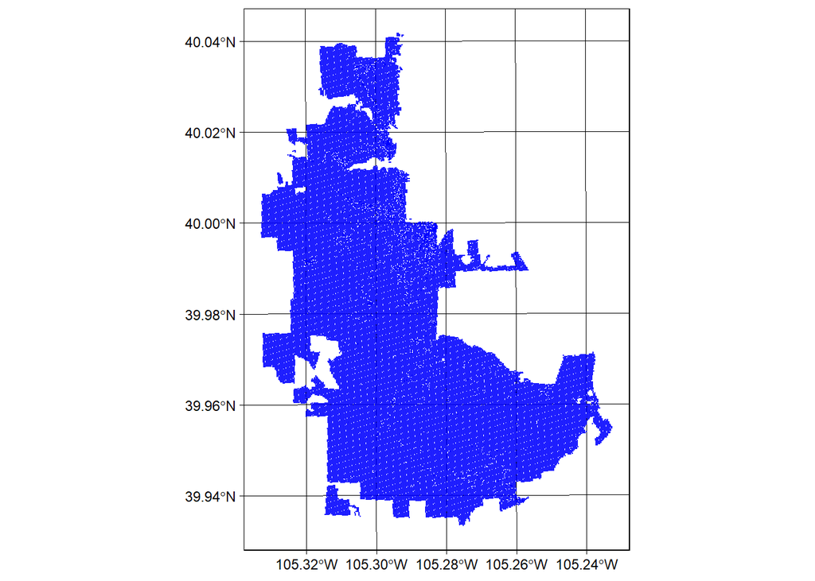

```r
# project the data using an appropriate projection for Colorado
boulder = st_transform(boulder, 26753)

# View the distribution of the point
ggplot() +
    geom_sf(data =boulder,
            title="Boulder Social Media",
            color="blue",
            size=0.05,
            fill = NA,
            alpha = 0.8,
            na.rm = TRUE,
            show.legend = NA,
            inherit.aes = TRUE)+
    theme_linedraw()
```

### Attributes

#### Source category and terrain

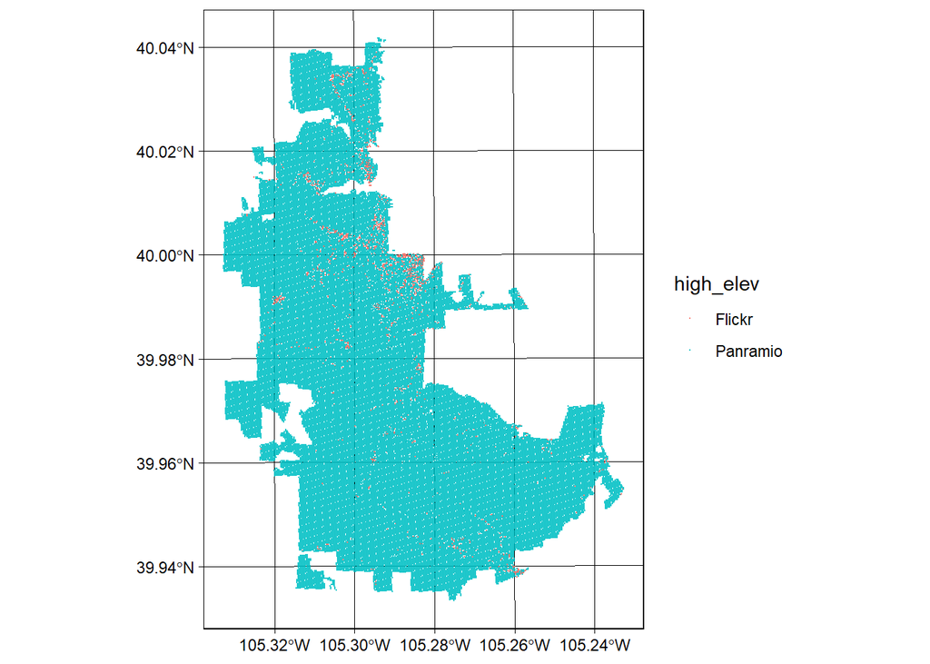

```r
# DB: indicates whether the point is a social media location (Flickr or Panramio) or a point in the park
boulder %>%
  mutate(high_elev = ifelse(DB == "Flickr", "Flickr", "Panramio"))%>%
  ggplot() +
  geom_sf(aes(color=high_elev),
          fill = NA,
          size=0.02,
          alpha = 0.8,
          na.rm = TRUE)  +
  theme_linedraw()
```

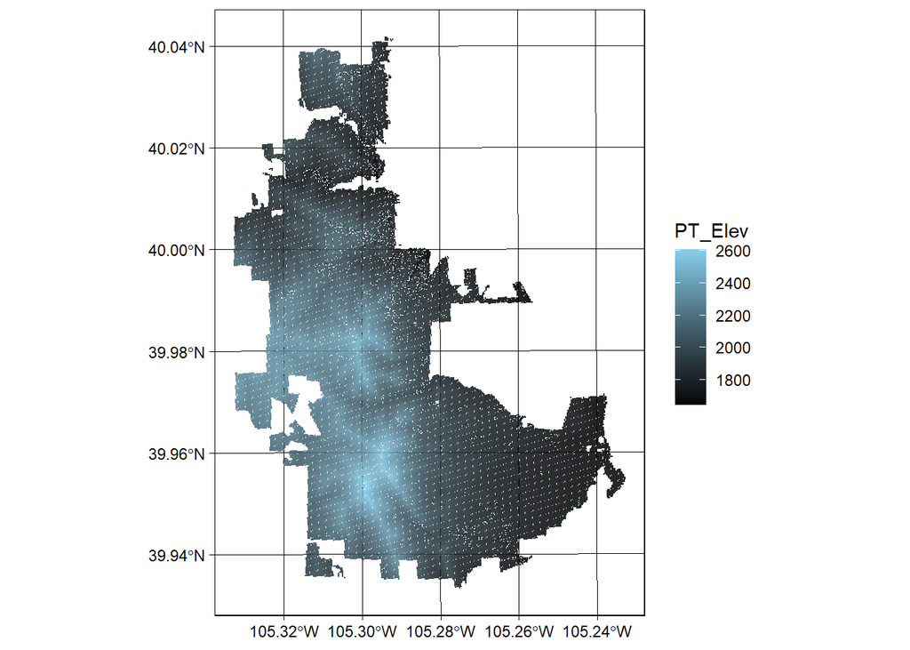

```r
# PT_Elev: Elevation
ggplot() +
    geom_sf(data =boulder,
            aes(color=PT_Elev),
            fill = NA,
            size=0.02,
            alpha = 0.8,
            na.rm = TRUE) +
  scale_colour_gradient(low = "black", high = "skyblue") +
  theme_linedraw()
```

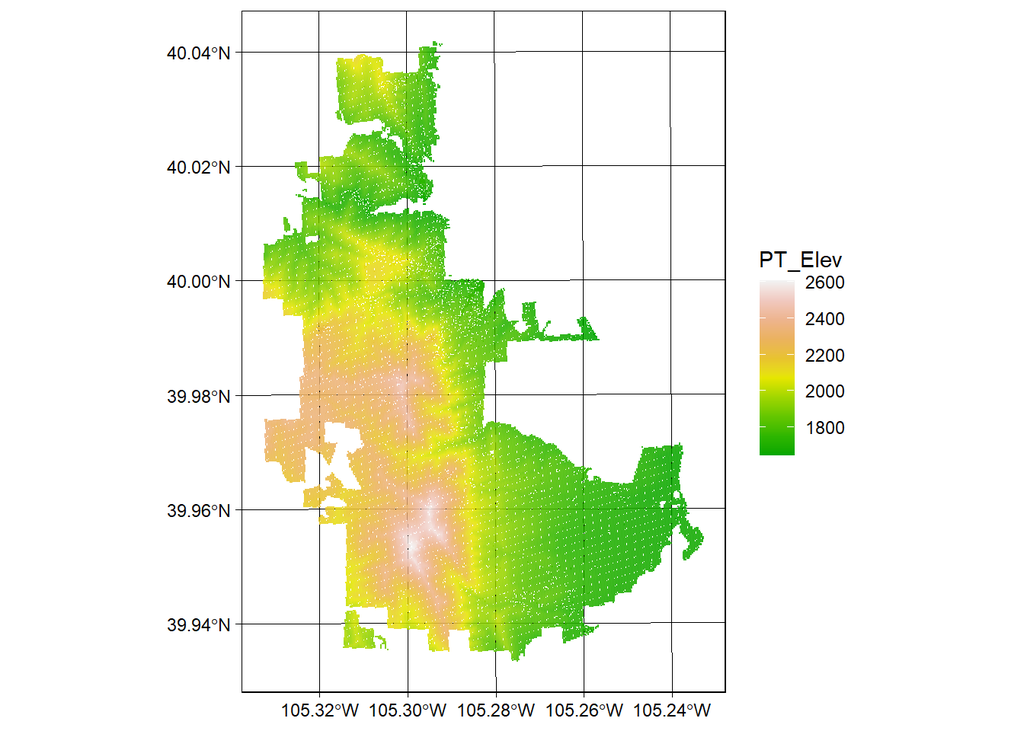

```r
# extent: extent that can be viewed at each point estimated through viewshed analysis
ggplot() +
    geom_sf(data =boulder,
            aes(color=PT_Elev),
            fill = NA,
            size=0.02,
            alpha = 0.8,
            na.rm = TRUE) +
  scale_colour_gradientn(colours = terrain.colors(10)) +
  theme_linedraw()
```

#### Distance to different facilities and landuse type

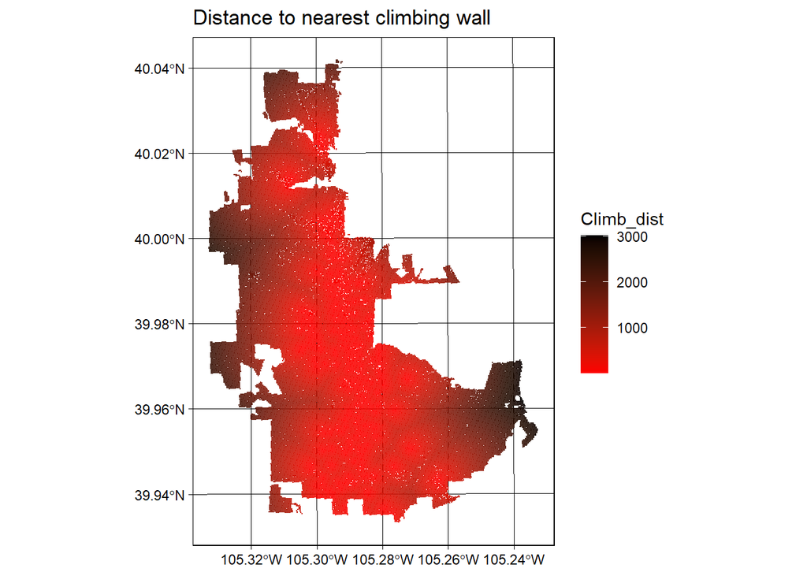

```r
# Climb_dist: distance to nearest climbing wall
ggplot() +
    geom_sf(data =boulder,
            aes(color=Climb_dist),
            fill = NA,
            size=0.02,
            alpha = 0.8,
            na.rm = TRUE) +
  scale_colour_gradient(low = "red", high = "black") +
  ggtitle("Distance to nearest climbing wall")+
  theme_linedraw()
```

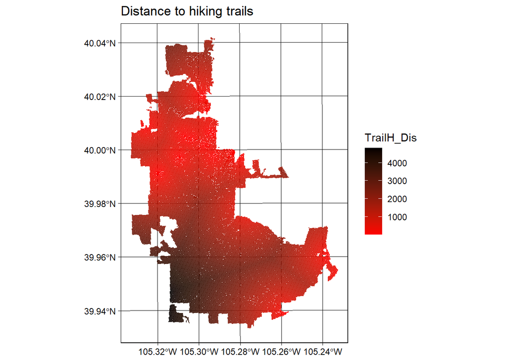

```r
# TrailH_Dis: distance to hiking trails
ggplot() +
    geom_sf(data =boulder,
            aes(color=TrailH_Dis),
            fill = NA,
            size=0.02,
            alpha = 0.8,
            na.rm = TRUE) +
  scale_colour_gradient(low = "red", high = "black") +
  ggtitle("Distance to hiking trails")+
  theme_linedraw()
```

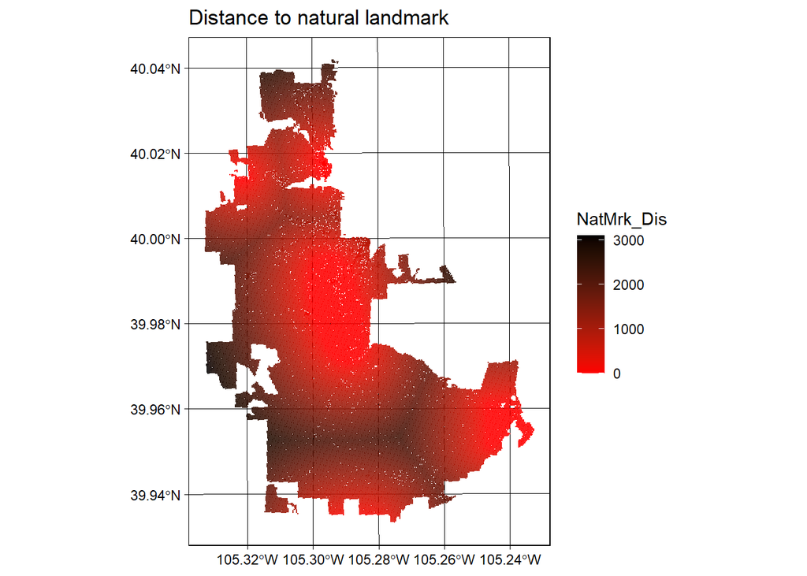

```r
# NatMrk_Dis: distance to natural landmark
ggplot() +
    geom_sf(data =boulder,
            aes(color=NatMrk_Dis),
            fill = NA,
            size=0.02,
            alpha = 0.8,
            na.rm = TRUE) +
  scale_colour_gradient(low = "red", high = "black") +
  ggtitle("Distance to natural landmark")+
  theme_linedraw()
```

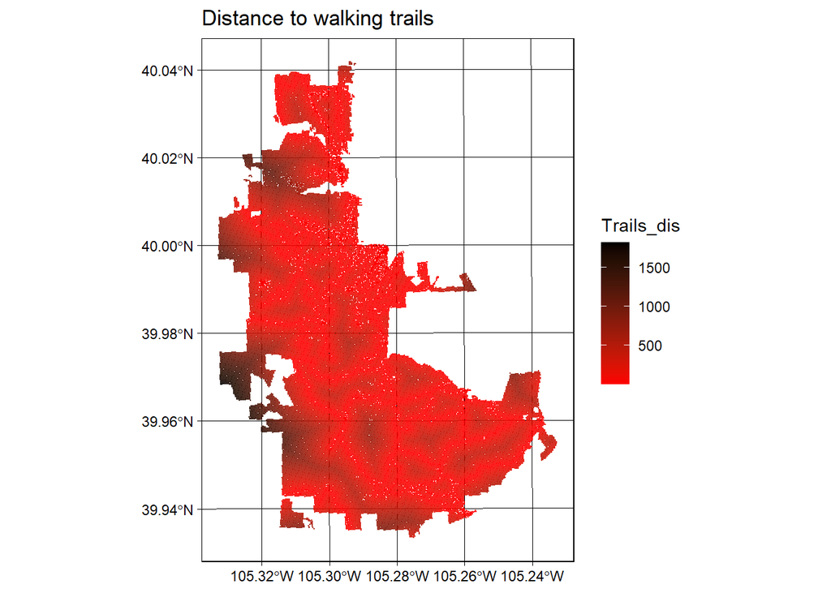

```r
# Trails_dis: distance to walking trails
ggplot() +
    geom_sf(data =boulder,
            aes(color=Trails_dis),
            fill = NA,
            size=0.02,
            alpha = 0.8,
            na.rm = TRUE) +
  scale_colour_gradient(low = "red", high = "black") +
  ggtitle("Distance to walking trails")+
  theme_linedraw()
```

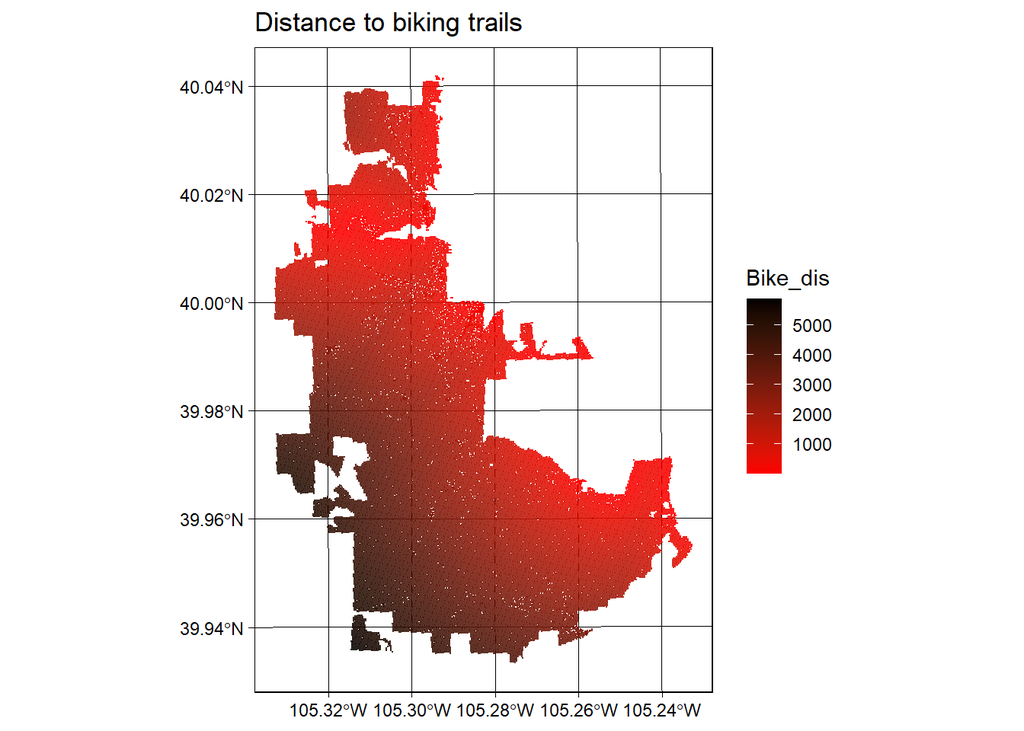

```r
# Bike_dis: distance to biking trails
ggplot() +
    geom_sf(data =boulder,
            aes(color=Bike_dis),
            fill = NA,
            size=0.02,
            alpha = 0.8,
            na.rm = TRUE) +
  scale_colour_gradient(low = "red", high = "black") +
  ggtitle("Distance to biking trails")+
  theme_linedraw()
```

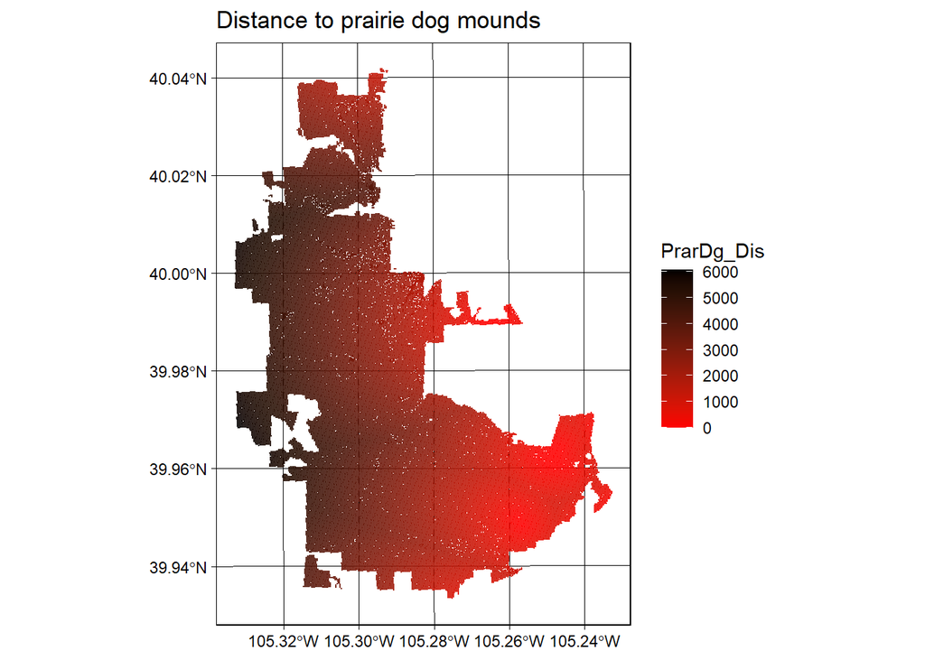

```r
# PrarDg_Dis: distance to prairie dog mounds
ggplot() +
    geom_sf(data =boulder,
            aes(color=PrarDg_Dis),
            fill = NA,
            size=0.02,
            alpha = 0.8,
            na.rm = TRUE) +
  scale_colour_gradient(low = "red", high = "black") +
  ggtitle("Distance to prairie dog mounds")+
  theme_linedraw()
```

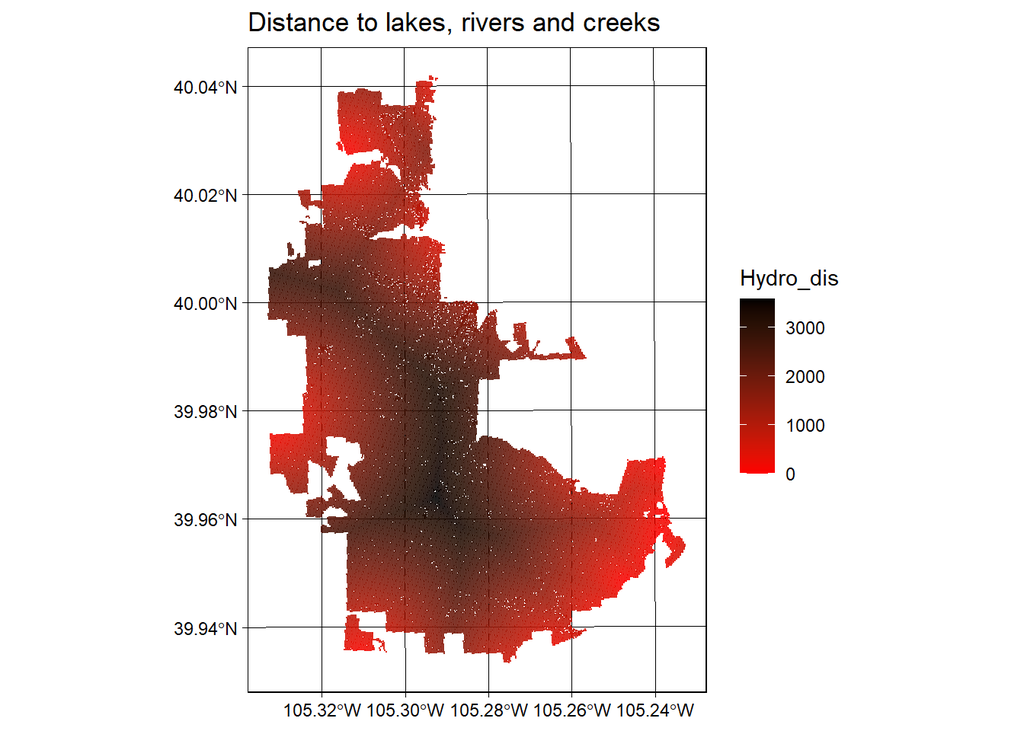

```r
# Hydro_dis: distance to lakes, rivers and creeks
ggplot() +
    geom_sf(data =boulder,
            aes(color=Hydro_dis),
            fill = NA,
            size=0.02,
            alpha = 0.8,
            na.rm = TRUE) +
  scale_colour_gradient(low = "red", high = "black") +
  ggtitle("Distance to lakes, rivers and creeks")+
  theme_linedraw()
```

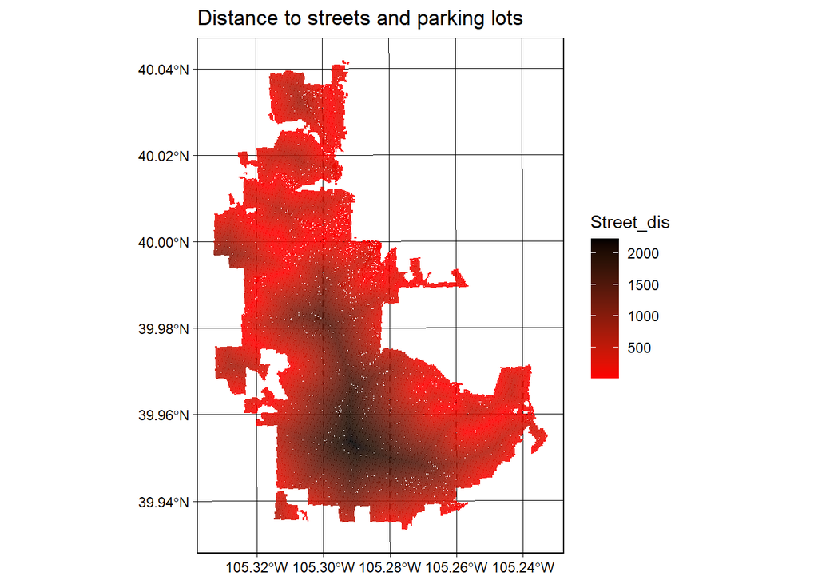

```r
# Street_dis: distance to streets and parking lots
ggplot() +
    geom_sf(data =boulder,
            aes(color=Street_dis),
            fill = NA,
            size=0.02,
            alpha = 0.8,
            na.rm = TRUE) +
  scale_colour_gradient(low = "red", high = "black") +
  ggtitle("Distance to streets and parking lots")+
  theme_linedraw()
```

## Analysis

### Accesibility

Since the spacial distribution indicated the location that people take photos, it comes to a question that how accessible the location is? Let’s say the nearest distance to a traffic facility (i.e. hiking trails, walking trails, biking trails, streets and parking lots) represent the accessibility of a location. And the smaller the distance is , the higher the accessibility is. Then we can calculate the accessibility by the equations below:
$$MinDistance_i = min(TrailHDis_i, Trailsdis_i,
Bikedis_i, Streetdis_i)$$
$$NormolizedMinDisatance_i =
(MinDistance_i-min(MinDistance))/(max(MinDistance)-min(MinDistance))$$
$$Accessibility_i=1-NormolizedMinDisatance_i$$

```r
# Calculate Accessibility
boulder <- boulder %>%
  mutate(MinDis = pmin(TrailH_Dis, Trails_dis, Bike_dis, Street_dis, na.rm = TRUE))%>%
  mutate(NorMinDis = (MinDis - min(MinDis, na.rm = TRUE)) / (max(MinDis, na.rm = TRUE) - min(MinDis, na.rm = TRUE))) %>%
  mutate(Accessibility = 1 - NorMinDis)

head(boulder)
```

*the result was hidden*

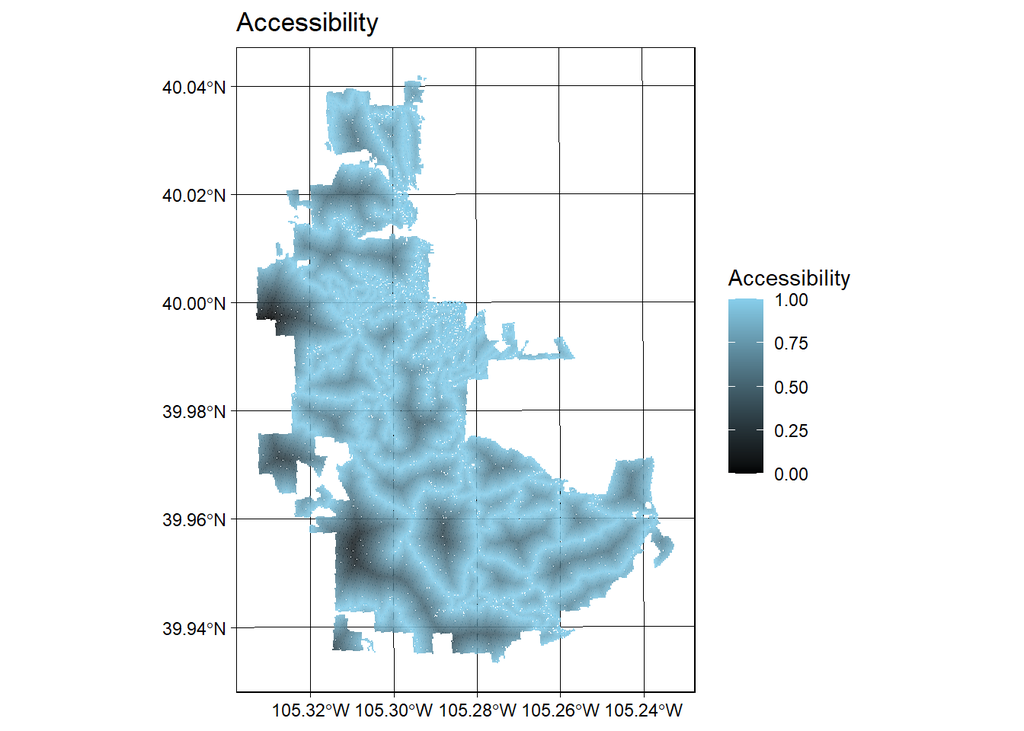

```r
# Visualize Accessibility
ggplot() +
    geom_sf(data =boulder,
            aes(color=Accessibility),
            fill = NA,
            size=0.02,
            alpha = 0.8,
            na.rm = TRUE) +
  scale_colour_gradient(low = "black", high = "skyblue") +
  ggtitle("Accessibility")+
  theme_linedraw()
```

Then here we know how accessible these locations are!

### Desirability Index

But were they worth going? Let’s calculate a Desirability Index based on the distance to the attractions(i.e. climbing wall, natural landmark, prairie dog mounds, lakes, rivers and creeks) to represent the attractiveness of each location. We can calculate the accessibility by the equations below:
$$Far_i=Climbdist_i+NatMrkDis_i+PrarDgDis_i+Hydrodis_i$$
$$NormalizedFar_i=(Far_i-min(Far))/(max(Far)-min(Far))$$
$$Desirability
Index=1-NormalizedFar_i$$

```r
# Calculate Desirability Index
boulder <- boulder %>%
  mutate(Far = Climb_dist+NatMrk_Dis+PrarDg_Dis+Hydro_dis)%>%
  mutate(NorFar = (Far - min(Far, na.rm = TRUE)) / (max(Far, na.rm = TRUE) - min(Far, na.rm = TRUE))) %>%
  mutate(Desirability = 1 - NorFar)

head(boulder)
```

*the result was hidden*

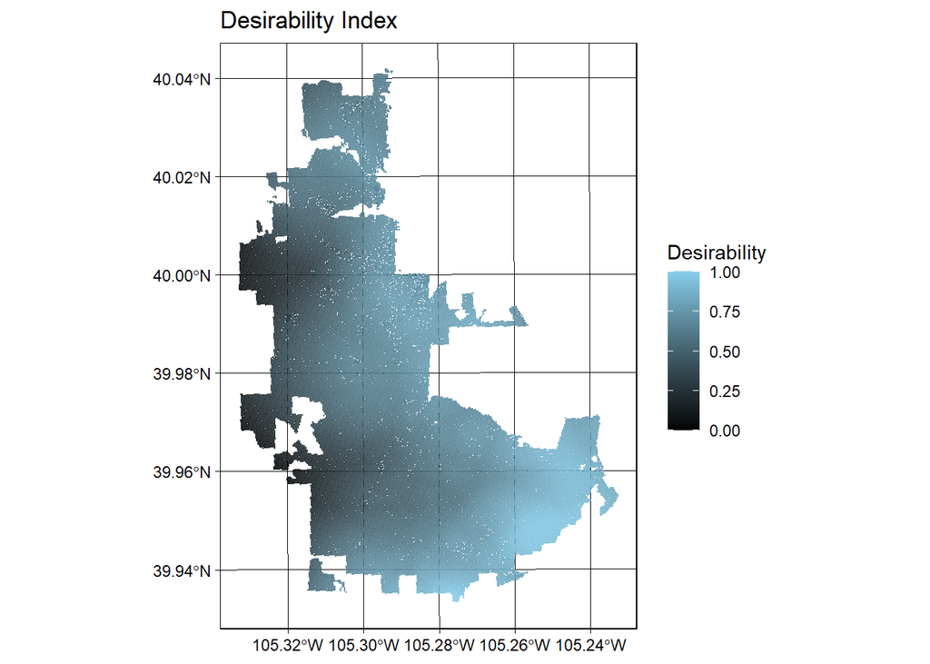

```r
# Visualize Desirability Index
ggplot() +
    geom_sf(data =boulder,
            aes(color=Desirability),
            fill = NA,
            size=0.02,
            alpha = 0.8,
            na.rm = TRUE) +
  scale_colour_gradient(low = "black", high = "skyblue") +
  ggtitle("Desirability Index")+
  theme_linedraw()
```

### Best Locations

Now we know how accesible and attractive a location is. It might be a good idea to select some place that are best to go based on this two indexs.

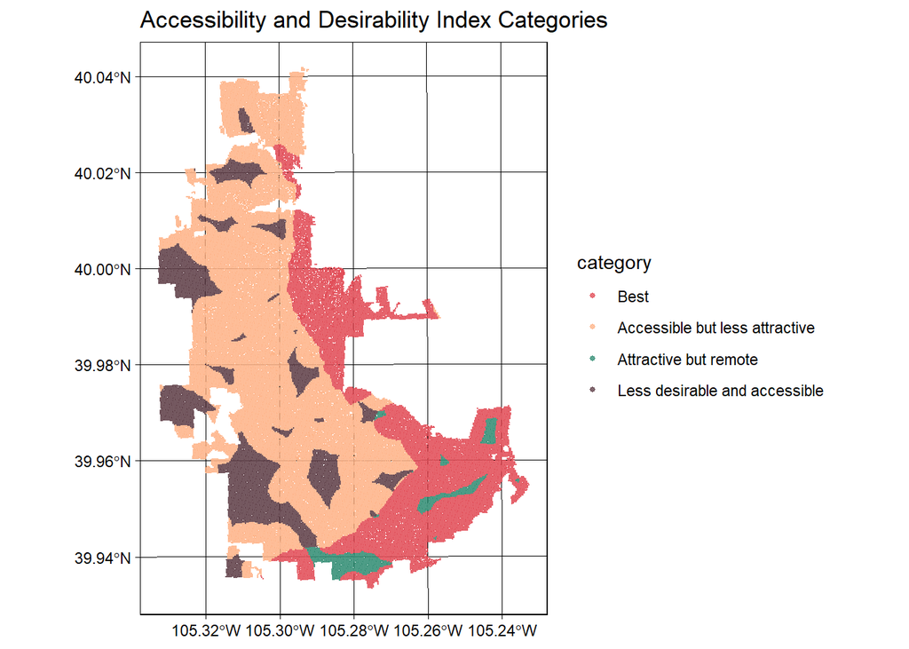

```r
# Create the categories
boulder <- boulder %>%
  mutate(category = case_when(
    Accessibility > 0.7 & Desirability > 0.7 ~ "Best",
    Accessibility > 0.7 & Desirability <= 0.7 ~ "Accessible but less attractive",
    Accessibility <= 0.7 & Desirability > 0.7 ~ "Attractive but remote",
    TRUE ~ "Less desirable and accessible"
  ))

# Define custom colors
custom_colors <- c("Best" = "#e24f59",
                   "Accessible but less attractive" = "#feb489",
                   "Attractive but remote" = "#358e75",
                   "Less desirable and accessible" = "#61414a")

# Plot with custom colors
ggplot(boulder) +
  geom_sf(aes(color = category), size = 0.02, alpha = 0.8) +
  scale_color_manual(
    values = custom_colors,
    limits = c("Best", "Accessible but less attractive", "Attractive but remote", "Less desirable and accessible")
  ) +
  labs(title = "Accessibility and Desirability Index Categories") +
  guides(color = guide_legend(override.aes = list(size = 1)))+
  theme_linedraw()
```

Finally, we have a map of 4 categories of locations, which indicates the accessibility and the attractiveness of the places in Colorado.